# STRIVE

Final Analysis

Hongxu Wang

08 August 2024

## Simple linear or logistic regression

**Exposure: normalized pfas**

**Covars (included sig vars found in exposure correlation, also excluding some vars): source (both), sex (both), age_at_enrollment (exposure), smoking (exposure), sq_average_drink_per_day (exposure)**

*sig vars from exposure correlation: ‘age_at_enrollment’,‘sex’,‘bmi’,‘sq_drink_alcohol’,‘sq_average_drink_per_day’, ‘smoking’,‘sq_water_bottled’,‘sq_water_other_type’, ‘sq_water_faucet_filter’,‘source_UNC’,‘source_DUKE’,‘source_Emory’,‘source_NCSU’* sig vars from exposure correlation:‘sex’, ‘source (reference: Emory)’,‘trig_mg_d_l’

**Outcome: natural log ALT, natural log AST, alt_cat1, ast_cat1, alt_cat2, ast_cat2**

*alt_cat1/ast_cat1: Norm: <= 29IU/L(males), <= 19IU/L(females); High: > 29IU/L(males), > 19IU/L(females)

*alt_cat2/ast_cat2: Norm: <= 33IU/L(males), <= 25IU/L(females); High: > 33IU/L(males), > 25IU/L(females) **Analysis: linear regression/logistic regression**

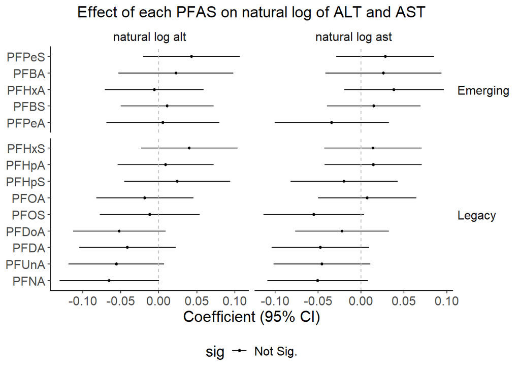

```r
# Perform linear regression using epiomics package
## outcome: natural log alt, natural log ast
covars <- c("source", "sex", "age_at_enrollment", "smoking", "sq_average_drink_per_day")

con_end <-c("log_alt", "log_ast")
con_end1 <-c("alt_cat1", "alt_cat2", "ast_cat1", "ast_cat2")

res_cont <- epiomics::owas(data,
                      var = con_end,
                      omics = pfas_name_scld,
                      covars = covars,
                      var_exposure_or_outcome = "outcome",
                      family = "gaussian",  # Use "gaussian" for linear regression
                      conf_int = TRUE)
## outcome: alt_cat1, ast_cat1, alt_cat2, ast_cat2
res_cat <- epiomics::owas(data,
                      var = con_end1,
                      omics = pfas_name_scld,
                      covars = covars,
                      var_exposure_or_outcome = "outcome",
                      family = "binomial",
                      conf_int = TRUE,
                      ref_group = "Normal")
res <- res_cont %>% mutate(outcome_type = "continuous") %>%
  bind_rows(res_cat %>% mutate(outcome_type ="categorical"))

# Adding sig variable to indicate the significance and rename PFAS
res1 <- res %>%
  mutate(sig = case_when((p_value < 0.05 & adjusted_pval < 0.05) ~ "Sig.(FDR < 0.05)",
                         p_value < 0.05 ~ "Sig.(p value < 0.05)",
                         TRUE ~ "Not Sig.")) %>%
  mutate(plot_name = case_when(
    grepl("pfba", feature_name) ~ "PFBA",
    grepl("pf_hp_a", feature_name) ~ "PFHpA",
    grepl("pf_pe_s", feature_name) ~ "PFPeS",
    grepl("pfbs", feature_name) ~ "PFBS",
    grepl("pf_hx_a", feature_name) ~ "PFHxA",
    grepl("pf_do_a", feature_name) ~ "PFDoA",
    grepl("pfda", feature_name) ~ "PFDA",
    grepl("pf_pe_a", feature_name) ~ "PFPeA",
    grepl("pf_un_a", feature_name) ~ "PFUnA",
    grepl("pfna", feature_name) ~ "PFNA",
    grepl("pfos", feature_name) ~ "PFOS",
    grepl("pf_hx_s", feature_name) ~ "PFHxS",
    grepl("pf_hp_s", feature_name) ~ "PFHpS",
    grepl("pfoa", feature_name) ~ "PFOA",
    grepl("pf3ons", feature_name) ~ "9CL-PF3ONS"
  ))%>%
  mutate(group = ifelse(feature_name %in% legacy_scld, "Legacy", "Emerging"))

res1$var_name<-factor(res1$var_name, levels=c("log_alt", "log_ast", "alt_cat1", "alt_cat2", "ast_cat1", "ast_cat2"), labels=c("natural log alt", "natural log ast", "lowest cut alt", "highest cut alt", "lowest cut ast", "highest cut ast"))

# Plot coefficients and confidence intervals----
## continuous alt and ast related outcomes
(plot1 <- ggplot(res1 %>% filter(outcome_type =="continuous"), aes(x = estimate, y = fct_reorder(plot_name, estimate), color = sig)) +
  geom_errorbar(aes(xmin = conf_low, xmax = conf_high), width = 0, position = position_dodge(width = 1)) +
  geom_point(size = 1, position = position_dodge(width = 1)) +
  geom_vline(xintercept = 0, linetype = 2, color = "grey") +
  facet_grid(group ~ var_name, scales = "free", space = "free_y") +
  labs(
    title = "Effect of each PFAS on natural log of ALT and AST",
    x = "Coefficient (95% CI)", y= "PFAS") +
  theme(
    legend.position = "bottom",
    panel.background = element_rect(fill="white"),
    strip.background = element_rect(fill = "white"),
    strip.text.y = element_text(angle = 0, hjust = 0),
    text = element_text(size = 15),
    axis.title.y = element_blank(),
    axis.line.x = element_line(color = "black"),
    axis.line.y = element_line(color = "black"),
    plot.title = element_text(size = 15, hjust = 0.5)
  ) +
  scale_color_manual(values = c("black", "red")))
```

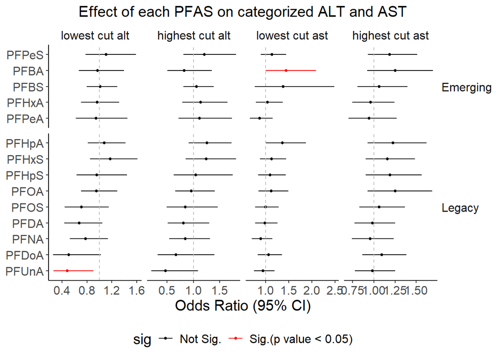

```r
## categorical alt and ast related outcomes----
(plot2 <- ggplot(res1 %>% filter(outcome_type =="categorical"), aes(x = exp(estimate), y = fct_reorder(plot_name, estimate), color = sig)) +
  geom_errorbar(aes(xmin = exp(conf_low), xmax = exp(conf_high)), width = 0, position = position_dodge(width = 1)) +
  geom_point(size = 1, position = position_dodge(width = 1)) +
  geom_vline(xintercept = 1, linetype = 2, color = "grey") +
  facet_grid(group ~ var_name, scales = "free", space = "free_y") +
  labs(
    title = "Effect of each PFAS on categorized ALT and AST",
    x = "Odds Ratio (95% CI)", y= "PFAS") +
  theme(
    legend.position = "bottom",
    panel.background = element_rect(fill="white"),
    strip.background = element_rect(fill = "white"),
    strip.text.y = element_text(angle = 0, hjust = 0),
    text = element_text(size = 15),
    axis.title.y = element_blank(),
    axis.line.x = element_line(color = "black"),
    axis.line.y = element_line(color = "black"),
    plot.title = element_text(size = 15, hjust = 0.5)
  ) +
  scale_color_manual(values = c("black", "red")))
```

```r
writexl::write_xlsx(res1, fs::path(dir_result, "pfas_alt_ast.xlsx"))
```

#Tables: Adjusted associations of individual PFAS and outcomes

```r
res <- readxl::read_xlsx(fs::path(dir_result,"pfas_alt_ast.xlsx"))%>%
  dplyr::select(var_name, plot_name, group, estimate:sig) %>%
  mutate(across(where(is.numeric), ~ round(., 3)))

res %>%
  filter(var_name == "natural log alt") %>%
  dplyr::select(plot_name, estimate, se, test_statistic,
                p_value, adjusted_pval,conf_low, conf_high)%>%
  gt() %>%
  tab_header(
    title = "Associations between exposures and ALT From Simple LR"
  ) %>%
  cols_label(
    plot_name = "PFAS",
    estimate = "Estimate",
    se = "Standard Error",
    test_statistic = "Statistic",
    p_value = "P-value",
    adjusted_pval = "Adjusted P-value",
    conf_low = "Lower CI",
    conf_high = "Upper CI"
  )
```

Associations between exposures and ALT From Simple LR

| PFAS | Estimate | Standard Error | Statistic | P-value | Adjusted P-value | Lower CI | Upper CI |
| --- | --- | --- | --- | --- | --- | --- | --- |
| PFDoA | -0.052 | 0.031 | -1.683 | 0.093 | 0.448 | -0.113 | 0.009 |
| PFHpA | 0.009 | 0.032 | 0.276 | 0.783 | 0.871 | -0.054 | 0.072 |
| PFHpS | 0.024 | 0.035 | 0.681 | 0.496 | 0.794 | -0.046 | 0.094 |
| PFHxA | -0.006 | 0.033 | -0.181 | 0.856 | 0.886 | -0.071 | 0.059 |
| PFHxS | 0.040 | 0.032 | 1.252 | 0.212 | 0.539 | -0.023 | 0.104 |
| PFPeA | 0.005 | 0.038 | 0.143 | 0.886 | 0.886 | -0.069 | 0.080 |
| PFPeS | 0.043 | 0.032 | 1.328 | 0.185 | 0.539 | -0.021 | 0.107 |
| PFUnA | -0.056 | 0.032 | -1.749 | 0.081 | 0.448 | -0.119 | 0.007 |
| PFBA | 0.023 | 0.038 | 0.588 | 0.557 | 0.794 | -0.053 | 0.098 |
| PFBS | 0.011 | 0.031 | 0.356 | 0.722 | 0.842 | -0.050 | 0.072 |
| PFDA | -0.041 | 0.032 | -1.282 | 0.201 | 0.539 | -0.105 | 0.022 |
| PFNA | -0.065 | 0.033 | -1.963 | 0.050 | 0.448 | -0.131 | 0.000 |
| PFOA | -0.018 | 0.033 | -0.568 | 0.570 | 0.794 | -0.083 | 0.046 |
| PFOS | -0.012 | 0.033 | -0.364 | 0.716 | 0.842 | -0.078 | 0.054 |

```r
res %>%
  filter(var_name == "natural log ast") %>%
  dplyr::select(plot_name, estimate, se, test_statistic,
                p_value, adjusted_pval,conf_low, conf_high)%>%
  gt() %>%
  tab_header(
    title = "Associations between exposures and AST From Simple LR"
  ) %>%
  cols_label(
    plot_name = "PFAS",
    estimate = "Estimate",
    se = "Standard Error",
    test_statistic = "Statistic",
    p_value = "P-value",
    adjusted_pval = "Adjusted P-value",
    conf_low = "Lower CI",
    conf_high = "Upper CI"
  )
```

Associations between exposures and AST From Simple LR

| PFAS | Estimate | Standard Error | Statistic | P-value | Adjusted P-value | Lower CI | Upper CI |
| --- | --- | --- | --- | --- | --- | --- | --- |
| PFDoA | -0.022 | 0.028 | -0.794 | 0.428 | 0.794 | -0.077 | 0.033 |
| PFHpA | 0.014 | 0.029 | 0.497 | 0.619 | 0.794 | -0.042 | 0.071 |
| PFHpS | -0.020 | 0.032 | -0.623 | 0.534 | 0.794 | -0.082 | 0.043 |
| PFHxA | 0.038 | 0.030 | 1.304 | 0.193 | 0.539 | -0.020 | 0.097 |
| PFHxS | 0.014 | 0.029 | 0.491 | 0.624 | 0.794 | -0.043 | 0.071 |
| PFPeA | -0.034 | 0.034 | -1.007 | 0.315 | 0.715 | -0.101 | 0.033 |
| PFPeS | 0.028 | 0.029 | 0.971 | 0.332 | 0.715 | -0.029 | 0.085 |
| PFUnA | -0.046 | 0.029 | -1.594 | 0.112 | 0.448 | -0.102 | 0.011 |
| PFBA | 0.026 | 0.034 | 0.766 | 0.444 | 0.794 | -0.041 | 0.094 |
| PFBS | 0.015 | 0.028 | 0.537 | 0.592 | 0.794 | -0.040 | 0.070 |
| PFDA | -0.047 | 0.029 | -1.643 | 0.101 | 0.448 | -0.104 | 0.009 |
| PFNA | -0.051 | 0.030 | -1.696 | 0.091 | 0.448 | -0.109 | 0.008 |
| PFOA | 0.007 | 0.029 | 0.243 | 0.808 | 0.871 | -0.050 | 0.064 |
| PFOS | -0.055 | 0.030 | -1.852 | 0.065 | 0.448 | -0.114 | 0.003 |

```r
res %>%
  filter(var_name == "lowest cut alt") %>%
  dplyr::select(plot_name, estimate, se, test_statistic,
                p_value, adjusted_pval, conf_low, conf_high) %>%
  mutate(
    estimate = exp(estimate),
    conf_low = exp(conf_low),
    conf_high = exp(conf_high)
  ) %>%
  gt() %>%
  tab_header(
    title = "Associations between exposures and ALT (defined by 29 in males and 19 in females) From Logistic Regression"
  ) %>%
  cols_label(
    plot_name = "PFAS",
    estimate = "Odds Ratio",
    se = "Standard Error",
    test_statistic = "Statistic",
    p_value = "P-value",
    adjusted_pval = "Adjusted P-value",
    conf_low = "Lower CI",
    conf_high = "Upper CI"
  ) %>%
  fmt_number(
    columns = vars(estimate, se, conf_low, conf_high),
    decimals = 3
  ) %>%
  fmt_number(
    columns = vars(p_value, adjusted_pval),
    decimals = 3,
    pattern = "{x}"
  ) %>%
  fmt_number(
    columns = vars(p_value, adjusted_pval),
    decimals = 3
  )
```

Associations between exposures and ALT (defined by 29 in males and 19 in females) From Logistic Regression

| PFAS | Odds Ratio | Standard Error | Statistic | P-value | Adjusted P-value | Lower CI | Upper CI |
| --- | --- | --- | --- | --- | --- | --- | --- |
| PFDoA | 0.511 | 0.355 | -1.887 | 0.059 | 0.733 | 0.255 | 1.026 |
| PFHpA | 1.077 | 0.141 | 0.522 | 0.602 | 0.933 | 0.816 | 1.420 |
| PFHpS | 0.958 | 0.209 | -0.204 | 0.838 | 0.936 | 0.636 | 1.442 |
| PFHxA | 0.963 | 0.160 | -0.240 | 0.810 | 0.936 | 0.704 | 1.315 |
| PFHxS | 1.171 | 0.163 | 0.973 | 0.331 | 0.859 | 0.852 | 1.611 |
| PFPeA | 0.947 | 0.216 | -0.252 | 0.801 | 0.936 | 0.620 | 1.448 |
| PFPeS | 1.110 | 0.182 | 0.570 | 0.569 | 0.933 | 0.776 | 1.587 |
| PFUnA | 0.485 | 0.316 | -2.285 | 0.022 | 0.733 | 0.261 | 0.902 |
| PFBA | 0.969 | 0.186 | -0.165 | 0.869 | 0.936 | 0.673 | 1.398 |
| PFBS | 1.013 | 0.121 | 0.105 | 0.916 | 0.936 | 0.799 | 1.284 |
| PFDA | 0.674 | 0.224 | -1.762 | 0.078 | 0.733 | 0.435 | 1.045 |
| PFNA | 0.775 | 0.194 | -1.310 | 0.190 | 0.820 | 0.530 | 1.134 |
| PFOA | 0.953 | 0.152 | -0.317 | 0.751 | 0.936 | 0.707 | 1.284 |
| PFOS | 0.713 | 0.242 | -1.392 | 0.164 | 0.768 | 0.444 | 1.148 |

```r
res %>%
  filter(var_name == "lowest cut ast") %>%
  dplyr::select(plot_name, estimate, se, test_statistic,
                p_value, adjusted_pval, conf_low, conf_high) %>%
  mutate(
    estimate = exp(estimate),
    conf_low = exp(conf_low),
    conf_high = exp(conf_high)
  ) %>%
  gt() %>%
  tab_header(
    title = "Associations between exposures and AST (defined by 29 in males and 19 in females) From Logistic Regression"
  ) %>%
  cols_label(
    plot_name = "PFAS",
    estimate = "Odds Ratio",
    se = "Standard Error",
    test_statistic = "Statistic",
    p_value = "P-value",
    adjusted_pval = "Adjusted P-value",
    conf_low = "Lower CI",
    conf_high = "Upper CI"
  ) %>%
  fmt_number(
    columns = vars(estimate, se, conf_low, conf_high, p_value, adjusted_pval),
    decimals = 3
  )
```

Associations between exposures and AST (defined by 29 in males and 19 in females) From Logistic Regression

| PFAS | Odds Ratio | Standard Error | Statistic | P-value | Adjusted P-value | Lower CI | Upper CI |
| --- | --- | --- | --- | --- | --- | --- | --- |
| PFDoA | 1.066 | 0.124 | 0.521 | 0.602 | 0.933 | 0.837 | 1.359 |
| PFHpA | 1.363 | 0.161 | 1.930 | 0.054 | 0.733 | 0.995 | 1.868 |
| PFHpS | 1.099 | 0.136 | 0.695 | 0.487 | 0.893 | 0.842 | 1.435 |
| PFHxA | 1.044 | 0.140 | 0.306 | 0.760 | 0.936 | 0.793 | 1.374 |
| PFHxS | 1.130 | 0.127 | 0.958 | 0.338 | 0.859 | 0.881 | 1.448 |
| PFPeA | 0.875 | 0.141 | -0.944 | 0.345 | 0.859 | 0.664 | 1.154 |
| PFPeS | 1.137 | 0.122 | 1.053 | 0.292 | 0.859 | 0.896 | 1.442 |
| PFUnA | 0.945 | 0.119 | -0.479 | 0.632 | 0.933 | 0.749 | 1.192 |
| PFBA | 1.448 | 0.187 | 1.975 | 0.048 | 0.733 | 1.003 | 2.090 |
| PFBS | 1.380 | 0.300 | 1.072 | 0.284 | 0.859 | 0.766 | 2.484 |
| PFDA | 0.988 | 0.123 | -0.101 | 0.919 | 0.936 | 0.776 | 1.256 |
| PFNA | 0.899 | 0.124 | -0.856 | 0.392 | 0.877 | 0.706 | 1.147 |
| PFOA | 1.126 | 0.143 | 0.828 | 0.407 | 0.877 | 0.850 | 1.490 |
| PFOS | 0.999 | 0.127 | -0.008 | 0.994 | 0.994 | 0.780 | 1.280 |

```r
res %>%
  filter(var_name == "highest cut alt") %>%
  dplyr::select(plot_name, estimate, se, test_statistic,
                p_value, adjusted_pval, conf_low, conf_high) %>%
  mutate(
    estimate = exp(estimate),
    conf_low = exp(conf_low),
    conf_high = exp(conf_high)
  ) %>%
  gt() %>%
  tab_header(
    title = "Associations between exposures and ALT (defined by 33 in males and 25 in females) From Logistic Regression"
  ) %>%
  cols_label(
    plot_name = "PFAS",
    estimate = "Odds Ratio",
    se = "Standard Error",
    test_statistic = "Statistic",
    p_value = "P-value",
    adjusted_pval = "Adjusted P-value",
    conf_low = "Lower CI",
    conf_high = "Upper CI"
  ) %>%
  fmt_number(
    columns = vars(estimate, se, conf_low, conf_high, p_value, adjusted_pval),
    decimals = 3
  )
```

Associations between exposures and ALT (defined by 33 in males and 25 in females) From Logistic Regression

| PFAS | Odds Ratio | Standard Error | Statistic | P-value | Adjusted P-value | Lower CI | Upper CI |
| --- | --- | --- | --- | --- | --- | --- | --- |
| PFDoA | 0.672 | 0.374 | -1.061 | 0.289 | 0.859 | 0.323 | 1.399 |
| PFHpA | 1.255 | 0.163 | 1.390 | 0.165 | 0.768 | 0.911 | 1.726 |
| PFHpS | 1.047 | 0.260 | 0.175 | 0.861 | 0.936 | 0.628 | 1.744 |
| PFHxA | 1.137 | 0.188 | 0.683 | 0.494 | 0.893 | 0.787 | 1.644 |
| PFHxS | 1.245 | 0.190 | 1.149 | 0.251 | 0.859 | 0.857 | 1.806 |
| PFPeA | 1.119 | 0.223 | 0.501 | 0.616 | 0.933 | 0.723 | 1.732 |
| PFPeS | 1.209 | 0.205 | 0.929 | 0.353 | 0.859 | 0.810 | 1.808 |
| PFUnA | 0.472 | 0.427 | -1.759 | 0.079 | 0.733 | 0.204 | 1.090 |
| PFBA | 0.826 | 0.251 | -0.762 | 0.446 | 0.885 | 0.505 | 1.350 |
| PFBS | 1.060 | 0.135 | 0.432 | 0.666 | 0.933 | 0.813 | 1.381 |
| PFDA | 0.815 | 0.238 | -0.863 | 0.388 | 0.877 | 0.511 | 1.298 |
| PFNA | 0.846 | 0.225 | -0.744 | 0.457 | 0.885 | 0.545 | 1.314 |
| PFOA | 0.959 | 0.196 | -0.216 | 0.829 | 0.936 | 0.653 | 1.408 |
| PFOS | 0.845 | 0.279 | -0.602 | 0.547 | 0.933 | 0.490 | 1.459 |

```r
res %>%
  filter(var_name == "highest cut ast") %>%
  dplyr::select(plot_name, estimate, se, test_statistic,
                p_value, adjusted_pval, conf_low, conf_high) %>%
  mutate(
    estimate = exp(estimate),
    conf_low = exp(conf_low),
    conf_high = exp(conf_high)
  ) %>%
  gt() %>%
  tab_header(
    title = "Associations between exposures and AST (defined by 33 in males and 25 in females) From Logistic Regression"
  ) %>%
  cols_label(
    plot_name = "PFAS",
    estimate = "Odds Ratio",
    se = "Standard Error",
    test_statistic = "Statistic",
    p_value = "P-value",
    adjusted_pval = "Adjusted P-value",
    conf_low = "Lower CI",
    conf_high = "Upper CI"
  ) %>%
  fmt_number(
    columns = vars(estimate, se, conf_low, conf_high, p_value, adjusted_pval),
    decimals = 3
  )
```

Associations between exposures and AST (defined by 33 in males and 25 in females) From Logistic Regression

| PFAS | Odds Ratio | Standard Error | Statistic | P-value | Adjusted P-value | Lower CI | Upper CI |
| --- | --- | --- | --- | --- | --- | --- | --- |
| PFDoA | 1.093 | 0.120 | 0.742 | 0.458 | 0.885 | 0.864 | 1.383 |
| PFHpA | 1.225 | 0.143 | 1.425 | 0.154 | 0.768 | 0.927 | 1.621 |
| PFHpS | 1.189 | 0.141 | 1.224 | 0.221 | 0.859 | 0.901 | 1.567 |
| PFHxA | 0.963 | 0.130 | -0.292 | 0.770 | 0.936 | 0.746 | 1.242 |
| PFHxS | 1.157 | 0.127 | 1.149 | 0.250 | 0.859 | 0.902 | 1.486 |
| PFPeA | 0.943 | 0.152 | -0.391 | 0.696 | 0.936 | 0.700 | 1.270 |
| PFPeS | 1.188 | 0.124 | 1.390 | 0.165 | 0.768 | 0.931 | 1.513 |
| PFUnA | 0.985 | 0.123 | -0.126 | 0.900 | 0.936 | 0.774 | 1.252 |
| PFBA | 1.250 | 0.156 | 1.429 | 0.153 | 0.768 | 0.920 | 1.699 |
| PFBS | 1.062 | 0.139 | 0.432 | 0.666 | 0.933 | 0.808 | 1.397 |
| PFDA | 0.982 | 0.124 | -0.141 | 0.888 | 0.936 | 0.770 | 1.254 |
| PFNA | 0.955 | 0.131 | -0.348 | 0.728 | 0.936 | 0.739 | 1.236 |
| PFOA | 1.251 | 0.153 | 1.467 | 0.142 | 0.768 | 0.928 | 1.689 |
| PFOS | 1.063 | 0.129 | 0.477 | 0.633 | 0.933 | 0.826 | 1.368 |